# An Empirical Evaluation of the IFPA Endorsement Fee

Phillip Grimaldi, Space City Pinball League

The purpose of this analysis is to provide a data driven perspective on the impact of the IFPA’s recent announcement to charge $1.00/per player for every tournament submission. My approach was to examine the 2016 calendar year as a proxy for determining the impact in future years. The data for this analysis was obtained directly from the IFPA via their API. Analysis code and data files are available at my [github repository](https://github.com/pgrimald/ifpa_fee). Readers are encouraged to report errors by contacting me directly or by submitting a pull request in github.

# How much money will this generate?

One of the stated purposes of the IFPA endorsement fee is to generate large prize pots for state and national championships. To this end, I began my analysis by determining how much money would have been generated in 2016. There was a total of 2,530 events in 2016. Based on the number of players attending these events, a total of $62,640 in prize money would have been generated. Twenty five percent of this amount would be have used for the national championship pot, which would have totaled $15,660.

Next, I estimated what the prize pots would have been for each state in 2016. The results are shown on the map below.

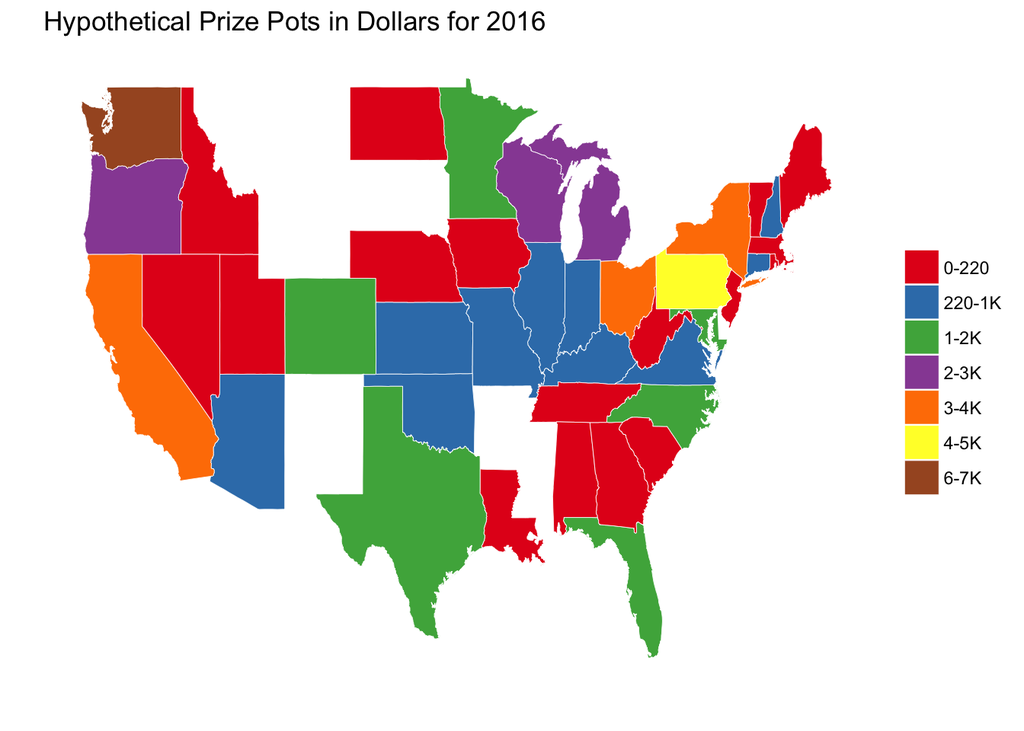

# What will this cost the typical player?

Next, I examined how much money would have been given to the IFPA by a typical player. In 2016, a total of 10,591 players participated in at least one tournament. This number may seem surprising to many, as the IFPA frequently advertises that it has over 50,000 players in their database. However, that number is a cumulative total. The number of players active at any given time is actually much lower.

For each player in 2016, I computed the number of events they attended in the 2016 year, and then computed the average dollar amount paid to the IFPA. In 2016, players would have paid $5.8 to the IFPA, on average. However, averages can be misleading and skewed by extreme values (e.g., a small subset of players who play in an extremely large number of events). To illustrate, a histogram of the number of events attended in 2016 is shown below.

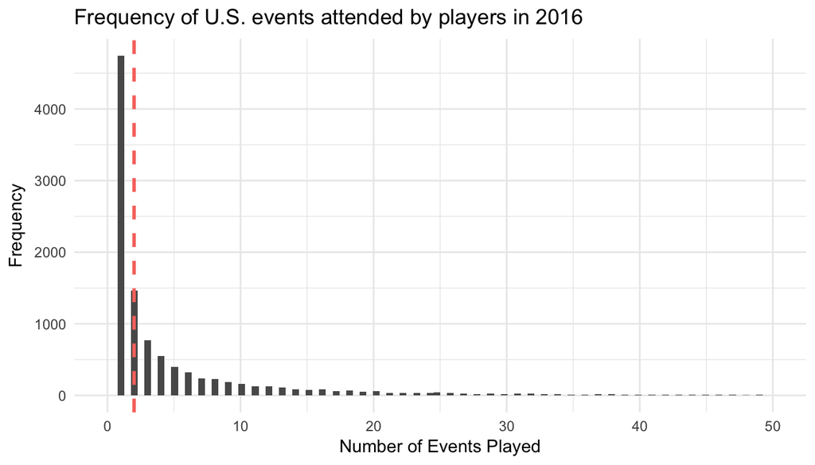

The histogram shows how frequently players attended tournaments in 2016. The red dotted line is the median (2). Note that the x-axis was shortened to improve readability of the figure (only 137 players attended more than 50 events). The most important thing to observe in the histogram is that the majority of players competed in 2 or fewer events across the 2016 season. Moreover, 4,743 played in only one tournament. In sum, this analysis suggests that the majority of players would have paid $2 or fewer in 2016, if the IFPA endorsement fee had been in effect.

This analysis was surprising for two reasons: 1) the player base is far smaller than I imagined, and 2) the majority of players are not that active. Based on these results, I wanted to examine how much players would have contributed to the pot, based on how active they were. To this end, I grouped players according to how many events they played in, and computed how much money they would have generated and what proportion of the pot that consisted of. The results are shown on the table below.

#### Hypothetical Dollars Generated By Events Played in 2016

|  | Number of Events Played | Number of Players | Proportion of Player Base | Dollars Generated | Proportion of Pot |
| --- | --- | --- | --- | --- | --- |
| 1 | 1-5 | 7929 | 0.75 | 14193 | 0.23 |
| 2 | 6-10 | 1128 | 0.11 | 8660 | 0.14 |
| 3 | 11-25 | 1026 | 0.1 | 16554 | 0.27 |
| 4 | 26-50 | 371 | 0.04 | 12861 | 0.21 |
| 5 | 51-100 | 132 | 0.01 | 8557 | 0.14 |
| 6 | 101-200 | 5 | 0 | 648 | 0.01 |

The table reveals yet another surprise. In particular, 75% of the entire 2016 player base played in only one to five events– meaning that 3 in 4 tournament players would have paid less than $5 to the IFPA in 2016. The vast majority of IFPA players do not appear to attend that many tournaments. More importantly, these “low activity” players would not have contributed a particularly large share of the pot for nationals. Rather, the majority of the pot would have been generated by higher activity players who played in more than 5 tournaments per year.

*See Appendix A below to view the hypothetical amount of fees collected from individual players in 2016.*

# What is the cost per player at the state level?

The above analysis examined the impact on individual players at a national level, but did not consider differences that may exist at the regional level. Indeed, it is well known that certain regions of the US are more active than others, and so the proposed IFPA endorsement fee may affect players differently in different regions of the US.

First, I examined how frequently players attended events in each state during the 2016 season. The results are shown on the figure below.

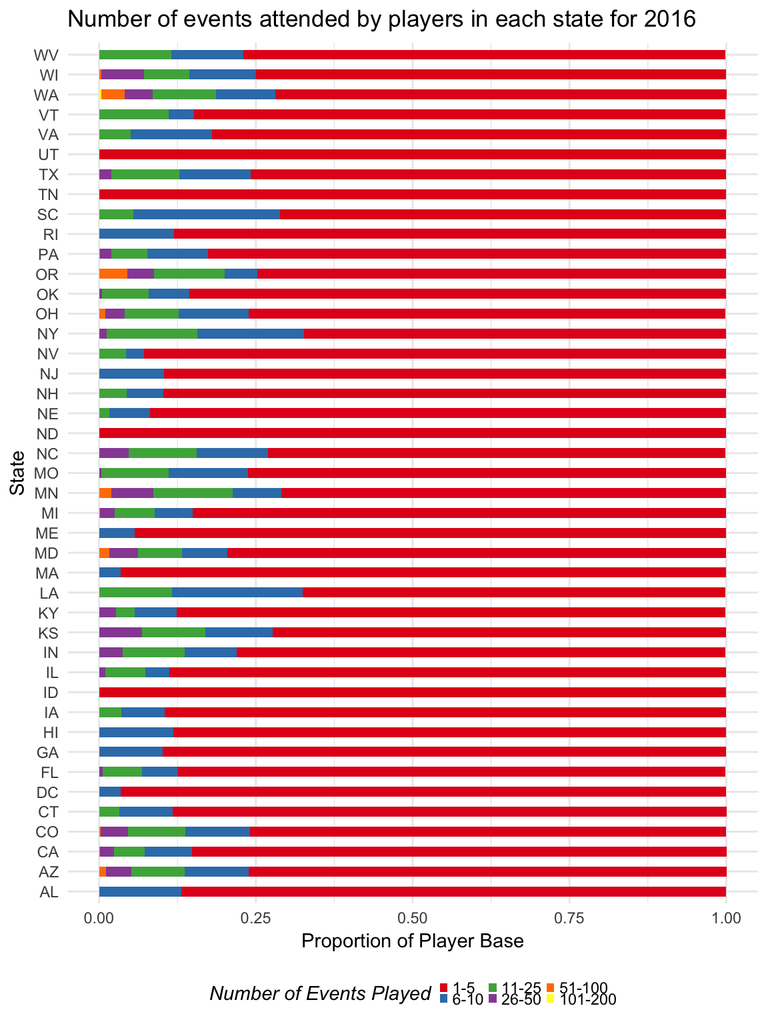

The figure shows that certain states do differ in terms of the proportion of highly active players. However, in every state, the majority of players are still “low-activity” players who only played in 1-5 events. This essentially mirrors the national findings previously discussed. Note that players who visited a state to play in a single tournament contributed to the “1-5” category in that state. This is why Pennsylvania had such a large number of players in the “1-5” category–many players visited PA to attend Pinburgh and PAPA.

After computing how many events players attended in each state, I was able to determine the dollar amount that each player would have had to pay to the IFPA. The maps below show the hypothetical average and median dollars per player that would have been given to the IFPA.

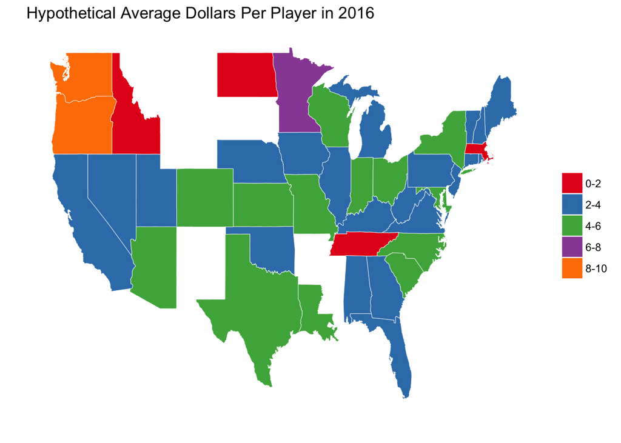

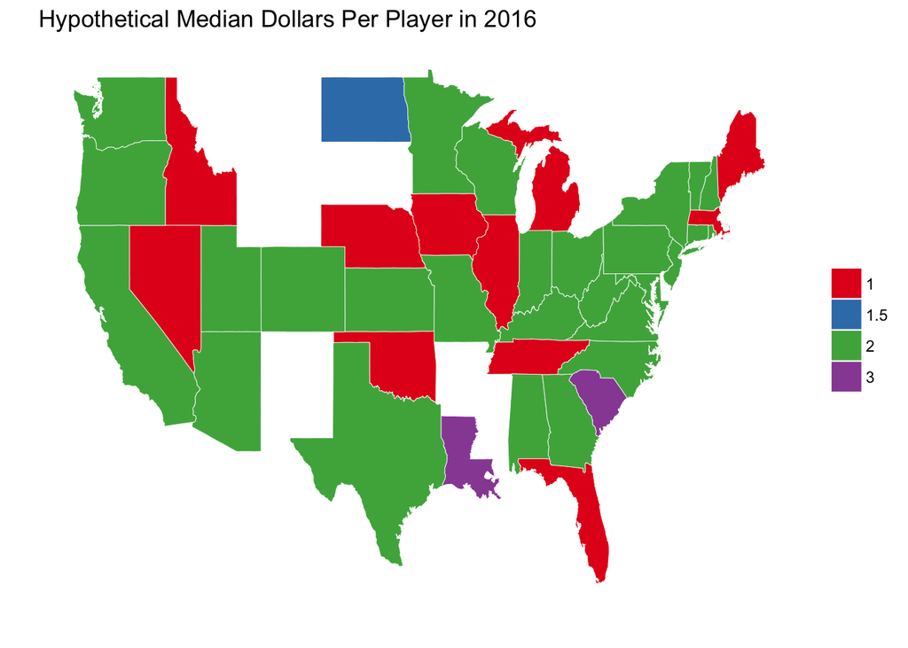

Indeed, the average price per player does vary considerably by state, with players in Washington and Oregon paying more dollars on average than other states. However, as mentioned previously, averages can be influenced heavily by extreme values. In such cases, the median is more appropriate. When considering the median, the cost per player given to the IFPA is much lower. Even in high activity states like Washington, the majority of players would have payed $2 or less to the IFPA in 2016.

*A full table of state values from 2016 is shown on Appendix B*

# Conclusions

The analysis described in this paper was intended to give an objective perspective on what the proposed IFPA endorsement fee will mean for players. The results suggest that for the vast majority of tournament players, the new IFPA endorsement fees will amount to a modest $2. This holds true for nearly all states participating in the SCS. While lower activity/newer player will generate a significant amount of the national pot, the majority of the pot will be generated by higher activity tournament players.

## Appendix A: Number of Events Attended in 2016 by Player

|  | Player ID | Last | First | Events Played |
| --- | --- | --- | --- | --- |
| 1 | 29083 | Chinn | Chris | 157 |
| 2 | 21384 | Robinson WA | John | 152 |
| 3 | 39139 | Larsen | Todd | 126 |
| 4 | 22985 | Philbeck | Alexa | 110 |
| 5 | 29141 | Mariolle | Germain | 103 |
| 6 | 21560 | Corbett WA | Mike | 100 |
| 7 | 22668 | Stakem | Steve | 98 |
| 8 | 38842 | Dobson | Howard | 98 |
| 9 | 24789 | Miazga | Derek | 96 |
| 10 | 1698 | Colbert | Nigel | 95 |

[output cut: 10581 more lines]

## Appendix B: Number of Events, Players, Fees and Estimated Players Costs by State in 2016

|  | state | Events | Players | Fees | Average Price/Player | Median Price/Player |
| --- | --- | --- | --- | --- | --- | --- |
| 1 | WA | 365 | 1013 | 8582 | 8.35 | 2 |
| 2 | PA | 142 | 1336 | 5479 | 3.78 | 2 |
| 3 | NY | 130 | 927 | 4749 | 5.03 | 2 |
| 4 | CA | 153 | 1147 | 4462 | 3.78 | 2 |
| 5 | OH | 150 | 776 | 4294 | 5.49 | 2 |
| 6 | OR | 106 | 421 | 3493 | 8.28 | 2 |
| 7 | MI | 117 | 720 | 2856 | 3.9 | 1 |
| 8 | WI | 121 | 472 | 2753 | 5.83 | 2 |
| 9 | MD | 91 | 431 | 2581 | 5.81 | 2 |
| 10 | TX | 96 | 500 | 2321 | 4.61 | 2 |

[output cut: 35 more lines]